# Untitled

## Uniformity test

- The Kolmogorov–Smirnov test on the DHARMa scaled residuals shows no deviation from the expected uniform distribution (D = 0.050, p = 0.929). **This indicates that the model’s residuals are well behaved and that there is no evidence of major distributional misspecification**.

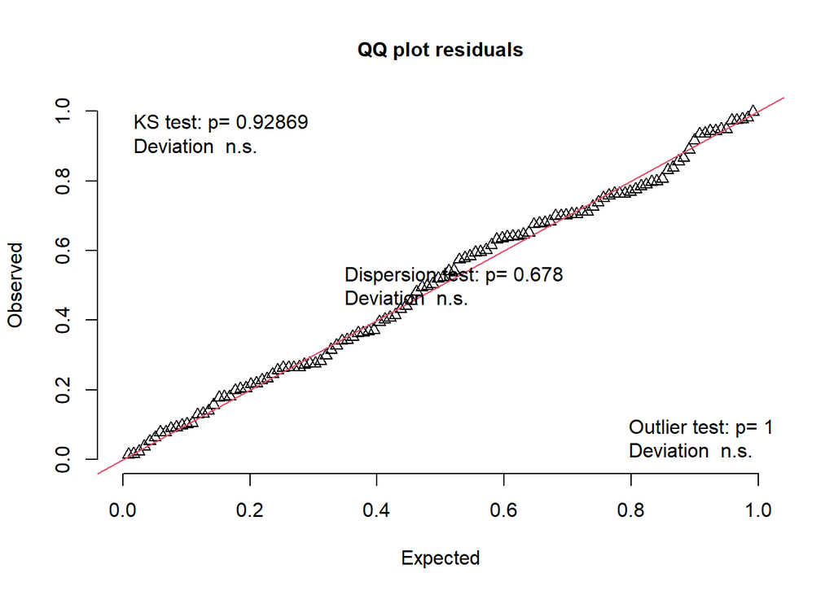

```
##
##  Asymptotic one-sample Kolmogorov-Smirnov test
##
## data:  simulationOutput$scaledResiduals
## D = 0.050081, p-value = 0.9287
## alternative hypothesis: two-sided
```

```r
testUniformity(res)
```

## Dispersion test

- The DHARMa dispersion test indicates that the model does not show evidence of overdispersion. The dispersion value is close to 1 (1.0662) and the high p-value (0.678) means we cannot reject the null hypothesis of correct dispersion. This suggests that the negative binomial GLMM adequately captures the variance structure of the count data.

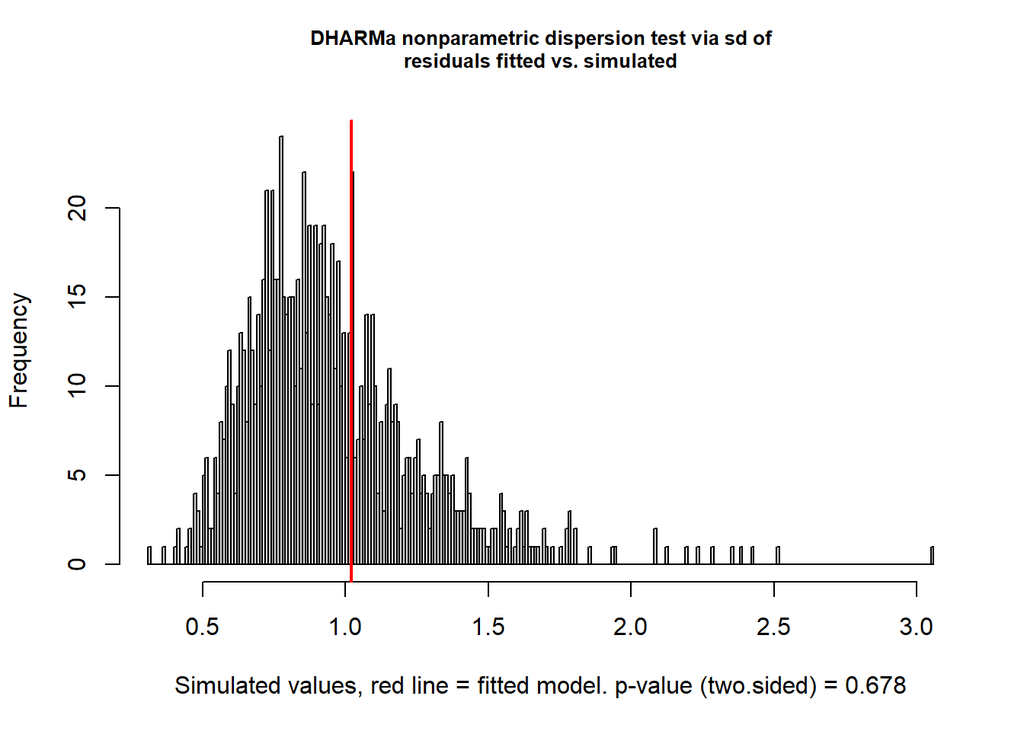

```
##
##  DHARMa nonparametric dispersion test via sd of residuals fitted vs.
##  simulated
##
## data:  simulationOutput
## dispersion = 1.0662, p-value = 0.678
## alternative hypothesis: two.sided
```

```r
testDispersion(res)
```